# BMIN503/EPID600 Project Template

Tuhina Srivastava

## **Overview**

This project aimed to spatially describe and statistically compare social determinants of health, COVID epidemiology, and election results to answer the question: Is there an association between county-level social determinants of health (ex. poverty rates, income), COVID-19 disease epidemiology (case and death rates), and recent election results (outcome for 2020 elections).

```
I spoke with the following faculty:
* Julia Lynch, PhD | Professor, Political Science, School of Arts and Sciences
* John H. Holmes | Professor, Biostatistics and Epidemiology, Perelman School of Medicine
```

Dr. Holmes advised that my question initially may have had a very obvious answer (conservative voting history may be associated with greater COVID cases and deaths). Dr. Lynch advised me to narrow my question and define it much more clearly, such as which sociodemographic factors I would use. Dr. Lynch also suggested that voter turnout might be an interesting metric that has not yet been looked at in this context. Furthermore, in order to go beyond a purely descriptive project, I could also assess if the socioeconomic status gradient in voting correlates with SES gradient in COVID epidemiology.

```
[Link to final project GitHub repository](https://github.com/tuhinas/BMIN503_Final_Project)
```

## **Introduction**

COVID-19 is an urgent and deadly public health crisis that has infected over 15.6 million Americans and claimed over 296,000 lives. Emerging evidence suggests that political partisanship has influenced individuals’ voluntary decisions to engage prevention practices such as distancing and mask-wearing (Grossman G, et.al., Proceedings of the National Academy of Sciences Sep 2020, 117 (39) 24144-24153; DOI: 10.1073/pnas.2007835117). Social determinants of health such as poverty and homelessness also have been linked to increased COVID-19 transmission (Abrams E, Szefler S. COVID-19 and the impact of social determinants of health. The Lancet Respiratory Medicine. 2020;8(7):659-661. doi:10.1016/s2213-2600(20)30234-4). Additionally, the COVID-19-associated death rates for Black and Latino people are 2-3 times higher than for white people, with these estimates rising further when adjusted for age.(Centers for Disease Control and Prevention, 2020) People of color, especially Black Americans, also have an elevated occupational risk of exposure to COVID-19 since they are more likely to be employed as “essential” workers, putting them in higher risk settings. These disparities span across all age groups and across rural to urban counties in numerous states. Underlying health conditions do not solely account for this, as inequities stemming from systemic racism can contribute to disease exposure, morbidity, and mortality at both the individual and neighborhood level. Existing data shows that areas with higher poverty rates, population density, and proportion of minority populations are associated with increased odds for infection. However, the 2020 Presidential election results compared alongside social determinants of health has not yet been evaluated in the context of COVID-19 epidemiology. Given the great partisan divide currently plaguing American politics and the catastrophic toll COVID-19 has had on Americans, such analyses are timely and important in understanding what populations are vulnerable to infection. Therefore, the objective of this analyses is to spatially describe and statistically compare social determinants of health. voting, and COVID-19 epidemiology.  
The problem described above is interdisciplinary because it looks at COVID-19 health outcomes in both a socioeconomic and political context. It is generally accepted that lower socioeconomic status is associated with lower civic engagement, and data has shown that higher levels of income inequality is associated with lower voter turnout (Galbraith, J., & Hale, J. (2008). State Income Inequality and Presidential Election Turnout and Outcomes. Social Science Quarterly, 89(4), 887-901. http://www.jstor.org/stable/42956351). Since COVID-19 transmission is both linked to socioeconomic status and influenced by personal behavior, interdisciplinary analyses using recent election results might help health officials better understand vulnerable populations in their communities. The partisan spin irrationally applied to mask-wearing practices and the lack of federal leadership has only amplified the partisan divide and amplified COVID-19 infections.

## **Methods**

### Data Sources

Publicly available data was used for all measures in this project. The county level Social Vulnerability Index (SVI) data, an index created by the Centers for Disease Control and Prevention (CDC) to evaluate a community’ ability to manage disaster response, was used for all socioeconomic status measures. The SVI uses data from 15 U.S. census variables on social factors in its creation. Although the SVI was designed for environmental disasters, it incorporates information about poverty, access to transportation, and population density, all which are relevant to infectious disease transmission. These SVI data are from 2018, the most recent publicly available SVI data set on the CDC website. Geographic county shapefiles were also obtained from the SVI data.  
Pennsylvania county-level COVID-19 case and death data was extracted from OpenData Pennsylvania, a portal to which the Pennsylvania Department of Health (DOH) uploads its COVID-19 data. The data includes all reported COVID-19 cases and deaths until December 1,2020. Presidential election data for 2020, which included Donald Trump and Joseph Biden raw votes counts by county, was downloaded from Politico which was sourced from the Associated Press. These data were also as recent as December 1, 2020. I chose to limit my analyses to Pennsylvania since it was a critical swing state in the 2020 Presidential election and has clearly segregated voting outcomes by county.  
### Analysis

Next, bivariate analyses using logistic regression were performed to determine associations between the dichotomized 2020 presidential election outcome (Trump vs. Biden) and all socioeconomic and COVID-19 (cases, deaths) predictors. Bivariate analyses using linear regression were also performed to determine associations between case and death rates and all socioeconomic and election outcome predictors. Case and death rates were chosen for this instead of cumulative/total counts to account for difference in population size between counties. Using a threshold of p = 0.15, variables were selected for inclusion in the final models. The threshold was selected as p = 0.15, a slightly more stringent than the commonly used p = 0.20 in the literature, to create a parsimonius model. Finally, multivariable logistic and linear regressions were used to look at associations between the 2020 presidential election outcome (Trump vs. Biden), COVID-19 case and death rates, all corresponding significant predictor variables to assess relationships. For the regression models, alpha = 0.05 was used to determine significance.

###Installing/loading R packages

```r
library(dplyr)
library(tidyverse)
library(sf)
library(tidycensus)
library(leaflet)
library(kableExtra)
```

```r
library(ggplot2)
library(cowplot)
library(gridExtra)
library(ggsn)
library(RColorBrewer)
library(viridis)
```

###Data Retrieval and Cleaning

####Importing CDC Social Vulnerability Index data

```r
#CDC Social Vulnerability Index Data
pa.svi.sf <- st_read("SVI2018_PENNSYLVANIA_county.shp")  # read shapefile as an sf object
class(pa.svi.sf)
```

```
## [1] "sf"         "data.frame"
```

```r
pa.svi.geo <- st_geometry(pa.svi.sf)
#plot(pa.svi.geo) #checking geometry
head(pa.svi.sf)
```

```
## Simple feature collection with 6 features and 125 fields
## geometry type:  MULTIPOLYGON
## dimension:      XY
## bbox:           xmin: -80.16529 ymin: 40.04035 xmax: -74.7215 ymax: 41.65183
## geographic CRS: NAD83
##   ST        STATE ST_ABBR       COUNTY  FIPS                          LOCATION AREA_SQMI E_TOTPOP M_TOTPOP   E_HU M_HU   E_HH M_HH E_POV M_POV E_UNEMP M_UNEMP E_PCI M_PCI E_NOHSDP M_NOHSDP E_AGE65 M_AGE65 E_AGE17 M_AGE17 E_DISABL M_DISABL E_SNGPNT M_SNGPNT E_MINRTY M_MINRTY E_LIMENG M_LIMENG E_MU…
## 1 42 PENNSYLVANIA      PA       Butler 42019       Butler County, Pennsylvania  788.5945   186566        0  82455  271  76240  632 14952   996    4118     445 36383   553     7163      505   33045      79   38197      26    22629      841     4635      429     9603      128      383      147    5…
## 2 42 PENNSYLVANIA      PA          Elk 42047          Elk County, Pennsylvania  827.3610    30608        0  17759   68  13727  229  2962   435     604     150 28476  1021     1721      212    6452      37    6007      74     4853      347     1072      190      781        8       46       78     …
## 3 42 PENNSYLVANIA      PA Westmoreland 42129 Westmoreland County, Pennsylvania 1028.0397   354751        0 170218  269 151665  902 34762  1507    7989     496 32916   434    15637      705   76650      60   65987      37    53865     1586     9620      570    21469      142     1044      248    8…
## 4 42 PENNSYLVANIA      PA        Bucks 42017        Bucks County, Pennsylvania  604.4277   626370        0 249732  373 237383 1075 37423  1928   15665     753 44103   424    27363     1216  110321      20  130567      42    67859     1563    14198      798    97394      475    10009      785   26…
## 5 42 PENNSYLVANIA      PA      Wyoming 42131      Wyoming County, Pennsylvania  397.3051    27588        0  13503  108  10784  225  2805   293     802     108 28810   933     1397      119    5433      25    5478      55     3729      243      881      114     1187       10       28       65     …
## 6 42 PENNSYLVANIA      PA        Perry 42099        Perry County, Pennsylvania  551.4480    45924        0  20784   76  18091  236  3848   433     887     154 29685   697     4056      264    8002      47    9960      18     6392      389     1360      172     2034       38      168       87     …
##   MP_UNEMP EP_PCI MP_PCI EP_NOHSDP MP_NOHSDP EP_AGE65 MP_AGE65 EP_AGE17 MP_AGE17 EP_DISABL MP_DISABL EP_SNGPNT MP_SNGPNT EP_MINRTY MP_MINRTY EP_LIMENG MP_LIMENG EP_MUNIT MP_MUNIT EP_MOBILE MP_MOBILE EP_CROWD MP_CROWD EP_NOVEH MP_NOVEH EP_GROUPQ MP_GROUPQ EPL_POV EPL_UNEMP EPL_PCI EPL_NOHSDP SPL_T…
## 1      0.5  36383    553       5.4       0.4     17.7      0.1     20.5      0.0      12.3       0.5       6.1       0.6       5.1       0.1       0.2       0.1      7.2      0.5       8.7       0.5      0.8      0.2      6.4      0.4       3.0       0.3  0.0606    0.1515  0.0758     0.0000     0…
## 2      0.9  28476   1021       7.7       0.9     21.1      0.1     19.6      0.2      16.0       1.1       7.8       1.4       2.6       0.0       0.2       0.3      2.5      0.6       6.9       0.9      0.7      0.4      7.4      1.2       1.3       0.3  0.1364    0.0909  0.4091     0.1970     0…
## 3      0.3  32916    434       6.0       0.3     21.6      0.1     18.6      0.0      15.3       0.5       6.3       0.4       6.1       0.0       0.3       0.1      5.0      0.3       5.8       0.3      0.6      0.1      7.4      0.4       2.3       0.1  0.1515    0.1970  0.1667     0.0606     0…
## 4      0.2  44103    424       6.1       0.3     17.6      0.1     20.8      0.0      10.9       0.3       6.0       0.3      15.5       0.1       1.7       0.1     10.8      0.4       1.9       0.1      1.1      0.2      4.8      0.3       1.5       0.1  0.0000    0.2424  0.0303     0.0758     0…
```

[output cut: 9 more lines]

```r
#Cleaning SVI shapefile to include variables of interest
pa.svi.sf.clean <- pa.svi.sf %>% dplyr::select(STATE, COUNTY, FIPS, E_POV, E_UNEMP, E_PCI, E_MINRTY, EP_POV, EP_UNEMP, RPL_THEME1, EP_UNINSUR, Shape_STAr, Shape_STLe)
pa.svi.sf.clean <- rename(pa.svi.sf.clean, Total.Poverty = E_POV) #Persons below poverty estimate, 2014-2018 ACS
pa.svi.sf.clean <- rename(pa.svi.sf.clean, Total.Unemployment = E_UNEMP) #Civilian (age 16+) unemployed estimate, 2014-2018 ACS
pa.svi.sf.clean <- rename(pa.svi.sf.clean, Income.Per.Capita = E_PCI) #Per capita income estimate, 2014-2018 ACS
pa.svi.sf.clean <- rename(pa.svi.sf.clean, Total.Minority.Persons = E_MINRTY) #Minority (all persons except white, non-Hispanic) estimate, 2014-2018 ACS
pa.svi.sf.clean <- rename(pa.svi.sf.clean, Percent.Poverty = EP_POV) #Percentage of persons below poverty estimate
pa.svi.sf.clean <- rename(pa.svi.sf.clean, Percent.Unemployment = EP_UNEMP) #Unemployment Rate estimate
pa.svi.sf.clean <- rename(pa.svi.sf.clean, Socioeconomic.Status = RPL_THEME1) #Socioeconomic Status consisting of percentile Below Poverty, Unemployed, Income, No High School Diploma - composite percentile based score
pa.svi.sf.clean <- rename(pa.svi.sf.clean, Percent.Uninsured = EP_UNINSUR) #Percentage Uninsured in the total civilian noninstitutionalized population estimate, 2014-2018 ACS
head(pa.svi.sf.clean)
```

```
## Simple feature collection with 6 features and 13 fields
## geometry type:  MULTIPOLYGON
## dimension:      XY
## bbox:           xmin: -80.16529 ymin: 40.04035 xmax: -74.7215 ymax: 41.65183
## geographic CRS: NAD83
##          STATE       COUNTY  FIPS Total.Poverty Total.Unemployment Income.Per.Capita Total.Minority.Persons Percent.Poverty Percent.Unemployment Socioeconomic.Status Percent.Uninsured Shape_STAr Shape_STLe                       geometry
## 1 PENNSYLVANIA       Butler 42019         14952               4118             36383                   9603             8.3                  4.2               0.0000               3.5  0.2200447   1.832488 MULTIPOLYGON (((-80.16529 4...
## 2 PENNSYLVANIA          Elk 42047          2962                604             28476                    781             9.8                  3.8               0.1212               3.1  0.2321498   2.592619 MULTIPOLYGON (((-79.09481 4...
## 3 PENNSYLVANIA Westmoreland 42129         34762               7989             32916                  21469            10.0                  4.4               0.0758               3.8  0.2842993   3.497394 MULTIPOLYGON (((-79.90487 4...
## 4 PENNSYLVANIA        Bucks 42017         37423              15665             44103                  97394             6.1                  4.5               0.0303               4.3  0.1707034   2.128708 MULTIPOLYGON (((-75.48406 4...
## 5 PENNSYLVANIA      Wyoming 42131          2805                802             28810                   1187            10.5                  5.8               0.2424               4.8  0.1131817   1.519193 MULTIPOLYGON (((-76.2831 41...
## 6 PENNSYLVANIA        Perry 42099          3848                887             29685                   2034             8.5                  3.7               0.1970               9.0  0.1526339   2.503137 MULTIPOLYGON (((-77.66925 4...
```

```r
pa.svi.geo.clean <- st_geometry(pa.svi.sf.clean)
#plot(pa.svi.geo.clean) #checking geometry
```

####Importing COVID-19 case and death data from OpenData Pennsylvania

```r
#COVID-19 cumulative case and death data by county by the PA Department of Health
covid19cases_PA <- read.csv("https://raw.githubusercontent.com/tuhinas/BMIN503_Final_Project/master/COVID-19_Aggregate_Cases_Current_Daily_County_Health.csv", header = TRUE, sep = ",")
head(covid19cases_PA)
```

```
##   Jurisdiction       Date New.Cases X7.day.Average.New.Cases Cumulative.cases Population..2018. New.Case.Rate X7.Day.Average.New.Case.Rate Cumulative.Case.Rate
## 1        Adams 03/01/2020         0                       NA                0            102811             0                           NA                    0
## 2        Adams 03/02/2020         0                       NA                0            102811             0                           NA                    0
## 3        Adams 03/03/2020         0                       NA                0            102811             0                           NA                    0
## 4        Adams 03/04/2020         0                       NA                0            102811             0                           NA                    0
## 5        Adams 03/05/2020         0                       NA                0            102811             0                           NA                    0
## 6        Adams 03/06/2020         0                       NA                0            102811             0                           NA                    0
```

```r
cases_recent <- filter(covid19cases_PA, Date == "12/01/2020") %>% select(Jurisdiction, Date, Cumulative.cases, Cumulative.Case.Rate)
cases_recent <- rename(cases_recent, County.Name = Jurisdiction)
head(cases_recent)
```

```
##    County.Name       Date Cumulative.cases Cumulative.Case.Rate
## 1       Warren 12/01/2020              333                843.1
## 2      Lebanon 12/01/2020             5550               3927.4
## 3        Blair 12/01/2020             4509               3681.1
## 4 Pennsylvania 12/01/2020           375431               2931.4
## 5  Northampton 12/01/2020             9444               3098.4
## 6        Berks 12/01/2020            14347               3414.7
```

```r
covid19deaths_PA <- read.csv("https://raw.githubusercontent.com/tuhinas/BMIN503_Final_Project/master/COVID-19_Aggregate_Death_Data_Current_Daily_County_Health.csv", header = TRUE, sep = ",")
head(covid19deaths_PA)
```

```
##   County.Name Date.of.Death New.Deaths X7.day.Average.New.Deaths Total.Deaths X2018.Population New.Deaths.Rate X7.day.Average.New.Death.Rate Total.Death.Rate
## 1       Adams    03/18/2020          0                        NA            0           102811               0                            NA                0
## 2       Adams    03/19/2020          0                        NA            0           102811               0                            NA                0
## 3       Adams    03/20/2020          0                        NA            0           102811               0                            NA                0
## 4       Adams    03/21/2020          0                        NA            0           102811               0                            NA                0
## 5       Adams    03/22/2020          0                        NA            0           102811               0                            NA                0
## 6       Adams    03/23/2020          0                        NA            0           102811               0                            NA                0
```

```r
deaths_recent <- filter(covid19deaths_PA, Date.of.Death == "12/01/2020") %>% select(County.Name, X2018.Population, Total.Deaths, Total.Death.Rate)
deaths_recent <- rename(deaths_recent, Population.2018 = X2018.Population)
head(deaths_recent)
```

```
##      County.Name Population.2018 Total.Deaths Total.Death.Rate
## 1         Carbon           64227           57            88.75
## 2 Northumberland           91083          136           149.31
## 3     Montgomery          828604          947           114.29
## 4        Cambria          131730           68            51.62
## 5       Delaware          564751          806           142.72
## 6       Bradford           60833           40            65.75
```

```r
covid.pa <- inner_join(cases_recent, deaths_recent, by = "County.Name") #joining cases and deaths based on county
head(covid.pa)
```

```
##    County.Name       Date Cumulative.cases Cumulative.Case.Rate Population.2018 Total.Deaths Total.Death.Rate
## 1       Warren 12/01/2020              333                843.1           39498            1             2.53
## 2      Lebanon 12/01/2020             5550               3927.4          141314          113            79.96
## 3        Blair 12/01/2020             4509               3681.1          122492           70            57.15
## 4 Pennsylvania 12/01/2020           375431               2931.4        12807060        10757            83.99
## 5  Northampton 12/01/2020             9444               3098.4          304807          337           110.56
## 6        Berks 12/01/2020            14347               3414.7          420152          463           110.20
```

```r
covid.pa <- rename(covid.pa, COUNTY = County.Name) #Renaming county variables for future inner join with other data
covid.pa$COUNTY[covid.pa$COUNTY == "Mckean"] <- "McKean" #Fixing misspelling in county name
```

####2020 Presidential Election Data - Pennsylvania

```r
#PA Election Data Sourced from Politico on 12/01/2020
pa.presidential.2020 <- read.csv("https://raw.githubusercontent.com/tuhinas/BMIN503_Final_Project/master/20201201_pa_results.csv", header = TRUE, sep = ",")
head(pa.presidential.2020)
```

```
##       COUNTY biden.votes biden.pct trump.votes trump.pct
## 1      Adams       18207      0.32       37523      0.66
## 2 Allegheny       430759      0.60      282913      0.39
## 3 Armstrong         8457      0.23       27489      0.76
## 4    Beaver        38122      0.41       54759      0.58
## 5   Bedford         4367      0.16       23025      0.84
## 6     Berks        92895      0.45      109736      0.53
```

```r
pa.presidential.2020$Winner #Creating Binary winner outcome
```

```r
pa.presidential.2020$Winner <- ifelse(pa.presidential.2020$biden.votes > pa.presidential.2020$trump.votes, "Biden", "Trump") #Generating winner per county
head(pa.presidential.2020)
```

```
##       COUNTY biden.votes biden.pct trump.votes trump.pct Winner
## 1      Adams       18207      0.32       37523      0.66  Trump
## 2 Allegheny       430759      0.60      282913      0.39  Biden
## 3 Armstrong         8457      0.23       27489      0.76  Trump
## 4    Beaver        38122      0.41       54759      0.58  Trump
## 5   Bedford         4367      0.16       23025      0.84  Trump
## 6     Berks        92895      0.45      109736      0.53  Trump
```

####Creating Aggregate Data Set with Social Vulnerability Index, COVID-19 Cases and Deaths, and 2020 Presidential Election Results

```r
#Checking consistency of number of rows
nrow(pa.svi.sf.clean)
```

```
## [1] 67
```

```r
nrow(covid.pa) #this dataset has an extra row for all of Pennsylvania
```

```
## [1] 68
```

```r
nrow(pa.presidential.2020)
```

```
## [1] 67
```

```r
covid.pa.clean <- covid.pa[-c(4),]
nrow(covid.pa.clean)
```

```
## [1] 67
```

```r
head(covid.pa.clean)
```

```
##        COUNTY       Date Cumulative.cases Cumulative.Case.Rate Population.2018 Total.Deaths Total.Death.Rate
## 1      Warren 12/01/2020              333                843.1           39498            1             2.53
## 2     Lebanon 12/01/2020             5550               3927.4          141314          113            79.96
## 3       Blair 12/01/2020             4509               3681.1          122492           70            57.15
## 5 Northampton 12/01/2020             9444               3098.4          304807          337           110.56
## 6       Berks 12/01/2020            14347               3414.7          420152          463           110.20
## 7       Bucks 12/01/2020            18296               2912.5          628195          704           112.07
```

```r
head(pa.presidential.2020)
```

```
##       COUNTY biden.votes biden.pct trump.votes trump.pct Winner
## 1      Adams       18207      0.32       37523      0.66  Trump
## 2 Allegheny       430759      0.60      282913      0.39  Biden
## 3 Armstrong         8457      0.23       27489      0.76  Trump
## 4    Beaver        38122      0.41       54759      0.58  Trump
## 5   Bedford         4367      0.16       23025      0.84  Trump
## 6     Berks        92895      0.45      109736      0.53  Trump
```

```r
pa.presidential.2020$COUNTY <- trimws(pa.presidential.2020$COUNTY, which = c("both"), whitespace = "[ \t\r\n]") #removing extra psace after some county names

#Creating aggregate data set with SVI, COVID-19, and 2020 Presidential election results
svi.covid <- inner_join(pa.svi.sf.clean, covid.pa.clean, by = "COUNTY")
svi.covid.geo <- st_geometry(svi.covid)
plot(svi.covid.geo)
head(svi.covid)
```

```
## Simple feature collection with 6 features and 19 fields
## geometry type:  MULTIPOLYGON
## dimension:      XY
## bbox:           xmin: -80.16529 ymin: 40.04035 xmax: -74.7215 ymax: 41.65183
## geographic CRS: NAD83
##          STATE       COUNTY  FIPS Total.Poverty Total.Unemployment Income.Per.Capita Total.Minority.Persons Percent.Poverty Percent.Unemployment Socioeconomic.Status Percent.Uninsured Shape_STAr Shape_STLe       Date Cumulative.cases Cumulative.Case.Rate Population.2018 Total.Deaths Total.Death.R…
## 1 PENNSYLVANIA       Butler 42019         14952               4118             36383                   9603             8.3                  4.2               0.0000               3.5  0.2200447   1.832488 12/01/2020             4750               2528.1          187888           82            43…
## 2 PENNSYLVANIA          Elk 42047          2962                604             28476                    781             9.8                  3.8               0.1212               3.1  0.2321498   2.592619 12/01/2020              582               1929.1           30169            6            19…
## 3 PENNSYLVANIA Westmoreland 42129         34762               7989             32916                  21469            10.0                  4.4               0.0758               3.8  0.2842993   3.497394 12/01/2020             9643               2750.3          350611          219            62…
## 4 PENNSYLVANIA        Bucks 42017         37423              15665             44103                  97394             6.1                  4.5               0.0303               4.3  0.1707034   2.128708 12/01/2020            18296               2912.5          628195          704           112…
## 5 PENNSYLVANIA      Wyoming 42131          2805                802             28810                   1187            10.5                  5.8               0.2424               4.8  0.1131817   1.519193 12/01/2020              480               1774.8           27046           25            92…
## 6 PENNSYLVANIA        Perry 42099          3848                887             29685                   2034             8.5                  3.7               0.1970               9.0  0.1526339   2.503137 12/01/2020              711               1541.0           46139           12            26…
```

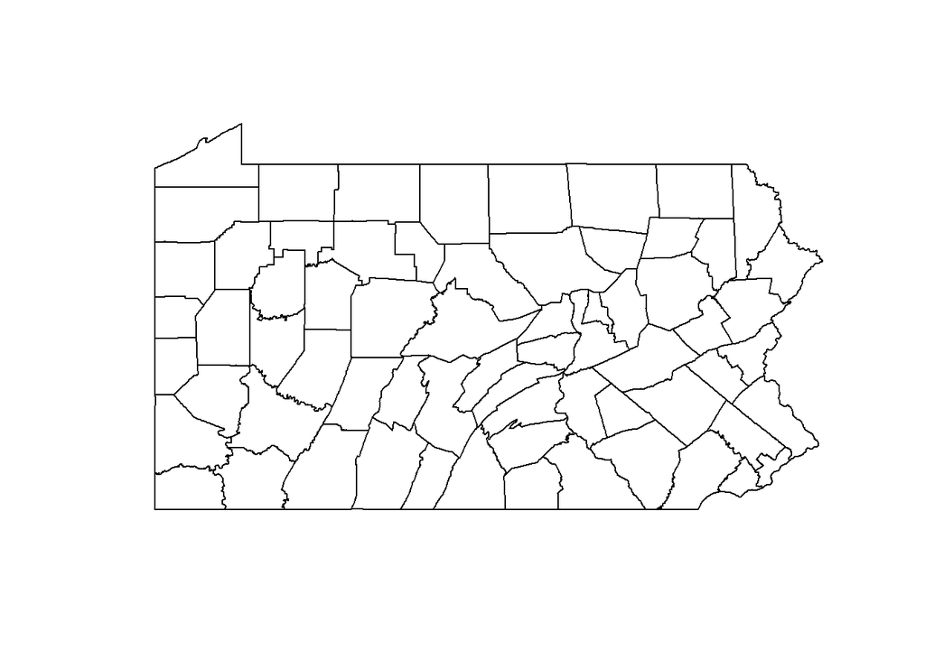

```r
pa.full <- inner_join(svi.covid, pa.presidential.2020, by = "COUNTY")
pa.full.geo <- st_geometry(pa.full)
plot(pa.full.geo)
```

```r
head(pa.full)
```

```
## Simple feature collection with 6 features and 24 fields
## geometry type:  MULTIPOLYGON
## dimension:      XY
## bbox:           xmin: -80.16529 ymin: 40.04035 xmax: -74.7215 ymax: 41.65183
## geographic CRS: NAD83
##          STATE       COUNTY  FIPS Total.Poverty Total.Unemployment Income.Per.Capita Total.Minority.Persons Percent.Poverty Percent.Unemployment Socioeconomic.Status Percent.Uninsured Shape_STAr Shape_STLe       Date Cumulative.cases Cumulative.Case.Rate Population.2018 Total.Deaths Total.Death.R…
## 1 PENNSYLVANIA       Butler 42019         14952               4118             36383                   9603             8.3                  4.2               0.0000               3.5  0.2200447   1.832488 12/01/2020             4750               2528.1          187888           82            43…
## 2 PENNSYLVANIA          Elk 42047          2962                604             28476                    781             9.8                  3.8               0.1212               3.1  0.2321498   2.592619 12/01/2020              582               1929.1           30169            6            19…
## 3 PENNSYLVANIA Westmoreland 42129         34762               7989             32916                  21469            10.0                  4.4               0.0758               3.8  0.2842993   3.497394 12/01/2020             9643               2750.3          350611          219            62…
## 4 PENNSYLVANIA        Bucks 42017         37423              15665             44103                  97394             6.1                  4.5               0.0303               4.3  0.1707034   2.128708 12/01/2020            18296               2912.5          628195          704           112…
## 5 PENNSYLVANIA      Wyoming 42131          2805                802             28810                   1187            10.5                  5.8               0.2424               4.8  0.1131817   1.519193 12/01/2020              480               1774.8           27046           25            92…
## 6 PENNSYLVANIA        Perry 42099          3848                887             29685                   2034             8.5                  3.7               0.1970               9.0  0.1526339   2.503137 12/01/2020              711               1541.0           46139           12            26…
```

```r
#Renaming Variables for clarity
pa.full <- rename(pa.full, Cumulative.Cases = Cumulative.cases)
pa.full <- rename(pa.full, Total.Biden.Votes = biden.votes)
pa.full <- rename(pa.full, Total.Biden.Percentage = biden.pct)
pa.full <- rename(pa.full, Total.Trump.Votes = trump.votes)
pa.full <- rename(pa.full, Total.Trump.Percentage = trump.pct)

#Factoring outcome for logistic regression
pa.full$pres.outcome #Creating Presidential outcome variable
```

```r
pa.full$pres.outcome <- as.factor(ifelse(pa.full$Winner == "Biden", 1, 0)) #Biden = 1
head(pa.full)
```

```
## Simple feature collection with 6 features and 25 fields
## geometry type:  MULTIPOLYGON
## dimension:      XY
## bbox:           xmin: -80.16529 ymin: 40.04035 xmax: -74.7215 ymax: 41.65183
## geographic CRS: NAD83
##          STATE       COUNTY  FIPS Total.Poverty Total.Unemployment Income.Per.Capita Total.Minority.Persons Percent.Poverty Percent.Unemployment Socioeconomic.Status Percent.Uninsured Shape_STAr Shape_STLe       Date Cumulative.Cases Cumulative.Case.Rate Population.2018 Total.Deaths Total.Death.R…
## 1 PENNSYLVANIA       Butler 42019         14952               4118             36383                   9603             8.3                  4.2               0.0000               3.5  0.2200447   1.832488 12/01/2020             4750               2528.1          187888           82            43…
## 2 PENNSYLVANIA          Elk 42047          2962                604             28476                    781             9.8                  3.8               0.1212               3.1  0.2321498   2.592619 12/01/2020              582               1929.1           30169            6            19…
## 3 PENNSYLVANIA Westmoreland 42129         34762               7989             32916                  21469            10.0                  4.4               0.0758               3.8  0.2842993   3.497394 12/01/2020             9643               2750.3          350611          219            62…
## 4 PENNSYLVANIA        Bucks 42017         37423              15665             44103                  97394             6.1                  4.5               0.0303               4.3  0.1707034   2.128708 12/01/2020            18296               2912.5          628195          704           112…
## 5 PENNSYLVANIA      Wyoming 42131          2805                802             28810                   1187            10.5                  5.8               0.2424               4.8  0.1131817   1.519193 12/01/2020              480               1774.8           27046           25            92…
## 6 PENNSYLVANIA        Perry 42099          3848                887             29685                   2034             8.5                  3.7               0.1970               9.0  0.1526339   2.503137 12/01/2020              711               1541.0           46139           12            26…
##                         geometry pres.outcome
## 1 MULTIPOLYGON (((-80.16529 4...            0
## 2 MULTIPOLYGON (((-79.09481 4...            0
## 3 MULTIPOLYGON (((-79.90487 4...            0
## 4 MULTIPOLYGON (((-75.48406 4...            1
## 5 MULTIPOLYGON (((-76.2831 41...            0
## 6 MULTIPOLYGON (((-77.66925 4...            0
```

### Logistic Regression

#### Bivariate Analyses for Variable Selection

```r
#We selected all variables not associated with geography and created a new data frame - logistic regression
pa.bivariate <- pa.full %>% dplyr::select(2, 4:11, 15:24, 26)
pa.bivariate <- as.data.frame(pa.bivariate)
pa.bivariate$pres.outcome <- as.factor(pa.bivariate$pres.outcome) #Making sure the outcome variable is a factor - Biden = 1
head(pa.bivariate)
```

```
##         COUNTY Total.Poverty Total.Unemployment Income.Per.Capita Total.Minority.Persons Percent.Poverty Percent.Unemployment Socioeconomic.Status Percent.Uninsured Cumulative.Cases Cumulative.Case.Rate Population.2018 Total.Deaths Total.Death.Rate Total.Biden.Votes Total.Biden.Percentage Total.T…
## 1       Butler         14952               4118             36383                   9603             8.3                  4.2               0.0000               3.5             4750               2528.1          187888           82            43.64             37508                   0.33        …
## 2          Elk          2962                604             28476                    781             9.8                  3.8               0.1212               3.1              582               1929.1           30169            6            19.89              4522                   0.27        …
## 3 Westmoreland         34762               7989             32916                  21469            10.0                  4.4               0.0758               3.8             9643               2750.3          350611          219            62.46             72129                   0.35        …
## 4        Bucks         37423              15665             44103                  97394             6.1                  4.5               0.0303               4.3            18296               2912.5          628195          704           112.07            204712                   0.52        …
## 5      Wyoming          2805                802             28810                   1187            10.5                  5.8               0.2424               4.8              480               1774.8           27046           25            92.44              4704                   0.32        …
## 6        Perry          3848                887             29685                   2034             8.5                  3.7               0.1970               9.0              711               1541.0           46139           12            26.01              5950                   0.24        …
```

```r
biv.pa <- cbind(Variable=rep(NA,20),P.Value=rep(NA,20)) #Creating a new data frame for bivariate associations output (variable name and p-value)
#Run bivariate logistic regression with outcome and 1 predictor each time in the loop
for (i in 2:20) {
 glm.pa <- glm(pres.outcome ~ pa.bivariate[[i]], data = pa.bivariate, family = binomial(logit))
 biv.pa[i, "Variable"] <- names(pa.bivariate[i])
 biv.pa[i, "P.Value"] <- summary(glm.pa)$coefficients[2,4]
 }
biv.pa <- as.data.frame(biv.pa)
biv.pa$P.Value <- as.numeric(biv.pa$P.Value)
#Variable Selection using common cutoff of p = 0.15
biv.var.sel <- biv.pa %>% filter(P.Value<0.15)
biv.var.sel[,"P.Value"] <- round(as.numeric(biv.var.sel[,"P.Value"]),3)
biv.var.sel %>% kbl() %>% kable_classic_2(full_width = F) %>% add_header_above(c(" ", "Table 1. Logistic Bivariate Analyses Results (Outcome: Presidential Election Winner)" = 1))
```

| Variable | Table 1. Logistic Bivariate Analyses Results (Outcome: Presidential Election Winner) P.Value |
| --- | --- |
| Total.Poverty | 0.000 |
| Total.Unemployment | 0.000 |
| Income.Per.Capita | 0.001 |
| Total.Minority.Persons | 0.000 |
| Socioeconomic.Status | 0.024 |
| Cumulative.Cases | 0.000 |
| Cumulative.Case.Rate | 0.071 |
| Population.2018 | 0.000 |
| Total.Deaths | 0.000 |
| Total.Death.Rate | 0.004 |
| Total.Biden.Votes | 0.001 |
| Total.Trump.Votes | 0.000 |

```r
#Linear Regression Variable Selection - Case Rate Outcome
biv.pa.linear <- cbind(Variable=rep(NA,20),P.Value=rep(NA,20)) #Creating a new data frame for bivariate associations output (variable name and p-value)
#Run bivariate logistic regression with outcome and 1 predictor each time in the loop
for (i in 2:20) {
 lm.pa <- lm(Cumulative.Case.Rate ~ pa.bivariate[[i]], data = pa.bivariate)
 biv.pa.linear[i, "Variable"] <- names(pa.bivariate[i])
 biv.pa.linear[i, "P.Value"] <- summary(lm.pa)$coefficients[2,4]
 }
biv.pa.linear <- as.data.frame(biv.pa.linear)
biv.pa.linear$P.Value <- as.numeric(biv.pa.linear$P.Value)
#Variable Selection using common cutoff of p = 0.15
biv.linear.varsel <- biv.pa.linear %>% filter(P.Value<0.15)
biv.linear.varsel[,"P.Value"] <- round(as.numeric(biv.linear.varsel[,"P.Value"]),3)
biv.linear.varsel %>% kbl() %>% kable_classic_2(full_width = F) %>% add_header_above(c(" ", "Table 2. Linear Bivariate Analyses Results (Outcome: Case Rate)" = 1))
```

| Variable | Table 2. Linear Bivariate Analyses Results (Outcome: Case Rate) P.Value |
| --- | --- |
| Total.Poverty | 0.011 |
| Total.Unemployment | 0.011 |
| Total.Minority.Persons | 0.016 |
| Percent.Uninsured | 0.009 |
| Cumulative.Cases | 0.001 |
| Cumulative.Case.Rate | 0.000 |
| Population.2018 | 0.011 |
| Total.Deaths | 0.002 |
| Total.Death.Rate | 0.000 |
| Total.Biden.Votes | 0.024 |
| Total.Biden.Percentage | 0.029 |
| Total.Trump.Votes | 0.021 |
| Total.Trump.Percentage | 0.030 |
| Winner | 0.065 |
| pres.outcome | 0.065 |

```r
#Linear Regression Variable Selection - Death Rate Outcome
biv.pa.lindeath <- cbind(Variable=rep(NA,20),P.Value=rep(NA,20)) #Creating a new data frame for bivariate associations output (variable name and p-value)
#Run bivariate logistic regression with outcome and 1 predictor each time in the loop
for (i in 2:20) {
 lmdeath.pa <- lm(Total.Death.Rate ~ pa.bivariate[[i]], data = pa.bivariate)
 biv.pa.lindeath[i, "Variable"] <- names(pa.bivariate[i])
 biv.pa.lindeath[i, "P.Value"] <- summary(lmdeath.pa)$coefficients[2,4]
 }
biv.pa.lindeath <- as.data.frame(biv.pa.lindeath)
biv.pa.lindeath$P.Value <- as.numeric(biv.pa.lindeath$P.Value)
#Variable Selection using common cutoff of p = 0.15
biv.lindeath.varsel <- biv.pa.lindeath %>% filter(P.Value<0.15)
biv.lindeath.varsel[,"P.Value"] <- round(as.numeric(biv.lindeath.varsel[,"P.Value"]),3)
biv.lindeath.varsel %>% kbl() %>% kable_classic_2(full_width = F) %>% add_header_above(c(" ", "Table 3. Linear Bivariate Analyses Results (Outcome: Death Rate)" = 1))
```

| Variable | Table 3. Linear Bivariate Analyses Results (Outcome: Death Rate) P.Value |
| --- | --- |
| Total.Poverty | 0.006 |
| Total.Unemployment | 0.001 |
| Income.Per.Capita | 0.004 |
| Total.Minority.Persons | 0.002 |
| Cumulative.Cases | 0.000 |
| Cumulative.Case.Rate | 0.000 |
| Population.2018 | 0.000 |
| Total.Deaths | 0.000 |
| Total.Death.Rate | 0.000 |
| Total.Biden.Votes | 0.001 |
| Total.Biden.Percentage | 0.000 |
| Total.Trump.Votes | 0.001 |
| Total.Trump.Percentage | 0.000 |
| Winner | 0.002 |
| pres.outcome | 0.002 |

#### Regression Models

```r
#Creating a new data frame with the outcome and variables chosen by variable selection
logistic.pa <- as.data.frame(pa.full) %>% dplyr::select(Total.Poverty, Total.Unemployment, Income.Per.Capita, Total.Minority.Persons, Socioeconomic.Status, Cumulative.Cases, Cumulative.Case.Rate, Population.2018, Total.Deaths, Total.Death.Rate, Total.Biden.Votes, Total.Trump.Votes, pres.outcome)
logistic.pa <- as.data.frame(logistic.pa)
logistic.pa$pres.outcome <- as.factor(logistic.pa$pres.outcome) #Making sure the outcome variable is a factor - Biden = 1

#Creating a full multivariable logistic model
glm.mvlogistic <- glm(pres.outcome ~ Total.Poverty + Total.Unemployment + Income.Per.Capita + Total.Minority.Persons + Socioeconomic.Status +  Cumulative.Cases + Cumulative.Case.Rate + Population.2018 + Total.Deaths + Total.Death.Rate, data = logistic.pa, family = binomial(logit))
summary(glm.mvlogistic)
```

```
##
## Call:
## glm(formula = pres.outcome ~ Total.Poverty + Total.Unemployment +
##     Income.Per.Capita + Total.Minority.Persons + Socioeconomic.Status +
##     Cumulative.Cases + Cumulative.Case.Rate + Population.2018 +
##     Total.Deaths + Total.Death.Rate, family = binomial(logit),
##     data = logistic.pa)
##
## Deviance Residuals:
##      Min        1Q    Median        3Q       Max
## -1.36493  -0.05299  -0.00583  -0.00030   1.75937
##
## Coefficients:
##                          Estimate Std. Error z value Pr(>|z|)
## (Intercept)            -3.116e+01  3.123e+01  -0.998   0.3185
## Total.Poverty           7.152e-04  4.573e-04   1.564   0.1179
## Total.Unemployment     -4.464e-04  1.424e-03  -0.313   0.7540
## Income.Per.Capita       4.472e-04  5.540e-04   0.807   0.4196
## Total.Minority.Persons  1.678e-04  1.155e-04   1.454   0.1461
## Socioeconomic.Status   -1.277e+01  1.542e+01  -0.828   0.4075
## Cumulative.Cases       -6.939e-03  3.926e-03  -1.768   0.0771 .
## Cumulative.Case.Rate    8.811e-03  5.450e-03   1.617   0.1060
## Population.2018         5.352e-05  6.880e-05   0.778   0.4366
## Total.Deaths            8.127e-02  6.183e-02   1.314   0.1887
## Total.Death.Rate       -1.151e-01  1.254e-01  -0.918   0.3585
## ---
## Signif. codes:  0 '***' 0.001 '**' 0.01 '*' 0.05 '.' 0.1 ' ' 1
##
## (Dispersion parameter for binomial family taken to be 1)
##
##     Null deviance: 65.495  on 65  degrees of freedom
## Residual deviance: 12.700  on 55  degrees of freedom
##   (1 observation deleted due to missingness)
## AIC: 34.7
##
## Number of Fisher Scoring iterations: 11
```

```r
exp(coef(glm.mvlogistic))
```

```
##            (Intercept)          Total.Poverty     Total.Unemployment      Income.Per.Capita Total.Minority.Persons   Socioeconomic.Status       Cumulative.Cases   Cumulative.Case.Rate        Population.2018           Total.Deaths       Total.Death.Rate
##           2.943865e-14           1.000715e+00           9.995537e-01           1.000447e+00           1.000168e+00           2.843996e-06           9.930851e-01           1.008850e+00           1.000054e+00           1.084667e+00           8.912782e-01
```

```r
confint(glm.mvlogistic) #Confidence intervals for fit
```

[output not shown]

[output cut: 226 more lines]

[output not shown]

```
##                                2.5 %        97.5 %
## (Intercept)            -1.589502e+02  2.4957553231
## Total.Poverty           1.934216e-04            NA
## Total.Unemployment     -3.953788e-03  0.0036022045
## Income.Per.Capita      -4.539325e-04  0.0024034266
## Total.Minority.Persons  7.485854e-06  0.0005328424
## Socioeconomic.Status   -6.207011e+01  9.6894886924
## Cumulative.Cases                  NA -0.0021847221
## Cumulative.Case.Rate    2.120461e-03            NA
## Population.2018        -2.791129e-05  0.0002826294
## Total.Deaths            4.615657e-03  0.3278636832
## Total.Death.Rate       -5.265692e-01  0.0472982100
```

```r
pval.results <- as.data.frame(coef(summary(glm.mvlogistic))[,4])
colnames(pval.results) <- "P.value"
multi.results <- as.data.frame(cbind(exp(cbind(OR = coef(glm.mvlogistic), CI = confint(glm.mvlogistic))), pval.results$P.value))  #OR, 95%CI, pvalue
```

[output not shown]

[output cut: 226 more lines]

[output not shown]

```r
multi.results <- rename(multi.results, P.value = V4)

#Logistic Regression with SES and Election
glm.sociologistic <- glm(pres.outcome ~ Total.Poverty + Total.Unemployment + Income.Per.Capita + Total.Minority.Persons + Socioeconomic.Status + Population.2018, data = logistic.pa, family = binomial(logit))
summary(glm.sociologistic)
```

```
##
## Call:
## glm(formula = pres.outcome ~ Total.Poverty + Total.Unemployment +
##     Income.Per.Capita + Total.Minority.Persons + Socioeconomic.Status +
##     Population.2018, family = binomial(logit), data = logistic.pa)
##
## Deviance Residuals:
##      Min        1Q    Median        3Q       Max
## -2.03835  -0.24893  -0.12160  -0.06291   2.01375
##
## Coefficients:
##                          Estimate Std. Error z value Pr(>|z|)
## (Intercept)            -1.630e+01  1.117e+01  -1.459   0.1445
## Total.Poverty           2.282e-04  1.191e-04   1.916   0.0553 .
## Total.Unemployment     -3.252e-04  6.906e-04  -0.471   0.6377
## Income.Per.Capita       4.623e-04  3.308e-04   1.398   0.1622
## Total.Minority.Persons  6.777e-05  4.236e-05   1.600   0.1096
## Socioeconomic.Status   -1.338e+00  5.105e+00  -0.262   0.7933
## Population.2018        -2.278e-05  1.656e-05  -1.376   0.1689
## ---
## Signif. codes:  0 '***' 0.001 '**' 0.01 '*' 0.05 '.' 0.1 ' ' 1
##
## (Dispersion parameter for binomial family taken to be 1)
##
##     Null deviance: 65.495  on 65  degrees of freedom
## Residual deviance: 24.582  on 59  degrees of freedom
##   (1 observation deleted due to missingness)
## AIC: 38.582
##
## Number of Fisher Scoring iterations: 8
```

```r
exp(coef(glm.sociologistic))
```

```
##            (Intercept)          Total.Poverty     Total.Unemployment      Income.Per.Capita Total.Minority.Persons   Socioeconomic.Status        Population.2018
##           8.303548e-08           1.000228e+00           9.996748e-01           1.000462e+00           1.000068e+00           2.624756e-01           9.999772e-01
```